# Prosper loan data EXPLORATION

## Preliminary Wrangling

> This data set contains 113,937 loans with 81 variables on each loan, including loan amount, borrower rate (or interest rate), current loan status, borrower income, and many others.

```python
# import all packages and set plots to be embedded inline
import numpy as np
import pandas as pd
import matplotlib.pyplot as plt
import seaborn as sb
import warnings
warnings.filterwarnings('ignore')

%matplotlib inline
```

```python
from IPython.display import HTML
HTML('''<script>
code_show_err=false;
function code_toggle_err() {
 if (code_show_err){
 $('div.output_stderr').hide();
 } else {
 $('div.output_stderr').show();
 }
 code_show_err = !code_show_err
}
$( document ).ready(code_toggle_err);
</script>
To toggle on/off output_stderr, click <a href="javascript:code_toggle_err()">here</a>.''')
```

To toggle on/off output_stderr, click here.

> Load in your dataset and describe its properties through the questions below. Try and motivate your exploration goals through this section.

```python
loans = pd.read_csv(r'C:\Users\Banana\Desktop\courses\data anaylsis udacity fwd\advanced\Third project\prosperLoanData.csv', header=0)
```

```python
loans.info()
```

```
<class 'pandas.core.frame.DataFrame'>
RangeIndex: 113937 entries, 0 to 113936
Data columns (total 81 columns):
 #   Column                               Non-Null Count   Dtype
---  ------                               --------------   -----
 0   ListingKey                           113937 non-null  object
 1   ListingNumber                        113937 non-null  int64
 2   ListingCreationDate                  113937 non-null  object
 3   CreditGrade                          28953 non-null   object
 4   Term                                 113937 non-null  int64
 5   LoanStatus                           113937 non-null  object
 6   ClosedDate                           55089 non-null   object
 7   BorrowerAPR                          113912 non-null  float64
 8   BorrowerRate                         113937 non-null  float64
 9   LenderYield                          113937 non-null  float64
```

[output cut: 73 more lines]

```python
print(loans.shape)
print(loans.dtypes)
print(loans.head(10))
```

```
(113937, 81)
ListingKey                      object
ListingNumber                    int64
ListingCreationDate             object
CreditGrade                     object
Term                             int64
                                ...
PercentFunded                  float64
Recommendations                  int64
InvestmentFromFriendsCount       int64
InvestmentFromFriendsAmount    float64
Investors                        int64
Length: 81, dtype: object
                ListingKey  ListingNumber            ListingCreationDate  \
0  1021339766868145413AB3B         193129  2007-08-26 19:09:29.263000000
```

[output cut: 71 more lines]

### What is the structure of my dataset?

> My dataset consists of 113937 records of loans data with 81 columns of different features starting from the ListingKey which is the Unique key for each listing going through features about the loan , borrower, lender and investors details and these are some of the important features of each:

> LOANS --- {LoanOriginalAmount , LoanOriginationQuarter: The quarter in which the loan was originated. Term : The length of the loan expressed in months , LoanStatus: The current status of the loan: Cancelled, Chargedoff, Completed, Current, Defaulted, FinalPaymentInProgress, PastDue. The PastDue status will be accompanied by a delinquency bucket , ListingCategory: The category of the listing that the borrower selected when posting their listing: 0 - Not Available, 1 - Debt Consolidation, 2 - Home Improvement, 3 - Business, 4 - Personal Loan, 5 - Student Use, 6 - Auto, 7- Other, 8 - Baby&Adoption, 9 - Boat, 10 - Cosmetic Procedure, 11 - Engagement Ring, 12 - Green Loans, 13 - Household Expenses, 14 - Large Purchases, 15 - Medical/Dental, 16 - Motorcycle, 17 - RV, 18 - Taxes, 19 - Vacation, 20 - Wedding Loans}

> BORROWER --- {BorrowerAPR: The Borrower's Annual Percentage Rate (APR) for the loan, BorrowerRate: The Borrower's interest rate for this loan , EmploymentStatus: The employment status of the borrower at the time they posted the listing, IsBorrowerHomeowner ,IncomeRange : The income range of the borrower at the time the listing was created, prosper score : }

> LENDER --- {LenderYield: The Lender yield on the loan. Lender yield is equal to the interest rate on the loan less the servicing fee , EstimatedEffectiveYield ,EstimatedLoss , EstimatedReturn}

> INVESTORS --- {Investors : The number of investors that funded the loan , InvestmentFromFriendsCount: Number of friends that made an investment in the loan , InvestmentFromFriendsAmount}

### What are the main features of interest in my dataset?

> I am most interested in the listing category , what types of loans are most applied for ? are they related to certain characteristics about the borrowers ?

> Interested too in the lender yield , what make the yield higher ? also loan status, What factors affect the loan status to be cancelled , completed or charged off ?

> Finally the investors , What factors makes more investors invest in a loan ?

### What features in the dataset will help support my investigation into my features of interest?

> For the listing category , The loan origin amount and The borrowers details features like employment staus , is the borrower a home owner , income range will have a strong relationship with the types of loans.

> For the loan status , The borrower rate , borrower APR , Prosper score of the borrower , LoanOriginalAmount , prosper rating , term and income range of the borrower all will affect the loan status.

##### Important note: the charged off loans means that their borrowers couldn't pay off their loans and the lender has uncounted their loans in his papers and given up on them leaving them to collection agencies that may collect any of the borrower belongings or properties to pay off.

> For the investors , I can see The listing category , the lender yield , loan amount and the borrower details features affects the number of investors that may invest a loan.

## Validating and cleaning

### What needs cleaning and validation ?

> From the factors we will be analyzing 1- BorrowerAPR and borrower Rate where the BorrowerAPR must be greater than borrower rate so we need to validate the 2 columns.

> From TotalProsperLoans---to--- ScorexChangeAtTimeOfListing columns , Their values will be null if the borrower had no prior loans. So we need to replace nulls with zeros.

```python
#Check values of borrower apr and borrower rate
loans['x'] = loans['BorrowerRate'] > loans['BorrowerAPR']
loans.x.value_counts()
```

```
False    113937
Name: x, dtype: int64
```

##### After I added column x that holds false for each value in borrower rate that is less than borrower Apr and counted the boolean values since all of them is false then we can say all the value are valid so let's remove the unncessary column now. I could validate that No borrower Rate value is higher than the borrowerAPR

```python
loans.drop('x', axis=1, inplace=True)
```

```python
#let's check nulls
loans.isnull().sum()
```

```
ListingKey                         0
ListingNumber                      0
ListingCreationDate                0
CreditGrade                    84984
Term                               0
                               ...
PercentFunded                      0
Recommendations                    0
InvestmentFromFriendsCount         0
InvestmentFromFriendsAmount        0
Investors                          0
Length: 81, dtype: int64
```

```python
#replace TotalProsperLoans---to--- ScorexChangeAtTimeOfListing columns nulls with zeros
loans['TotalProsperLoans'] = loans['TotalProsperLoans'].fillna(0)
loans['OnTimeProsperPayments'] = loans['OnTimeProsperPayments'].fillna(0)
loans['TotalProsperPaymentsBilled'] = loans['TotalProsperPaymentsBilled'].fillna(0)
loans['ProsperPaymentsLessThanOneMonthLate'] = loans['ProsperPaymentsLessThanOneMonthLate'].fillna(0)
loans['ProsperPrincipalBorrowed'] = loans['ProsperPrincipalBorrowed'].fillna(0)
loans['ScorexChangeAtTimeOfListing'] = loans['ScorexChangeAtTimeOfListing'].fillna(0)
```

```python
#check duplicates
loans.duplicated(subset=None, keep='first')
```

```
0         False
1         False
2         False
3         False
4         False
          ...
113932    False
113933    False
113934    False
113935    False
113936    False
Length: 113937, dtype: bool
```

## Univariate Exploration

> I'll start investigating the listing category and see what type of loans are most applied for.

> listing category : 0 - Not Available, 1 - Debt Consolidation, 2 - Home Improvement, 3 - Business, 4 - Personal Loan, 5 - Student Use, 6 - Auto, 7- Other, 8 - Baby&Adoption, 9 - Boat, 10 - Cosmetic Procedure, 11 - Engagement Ring, 12 - Green Loans, 13 - Household Expenses, 14 - Large Purchases, 15 - Medical/Dental, 16 - Motorcycle, 17 - RV, 18 - Taxes, 19 - Vacation, 20 - Wedding Loans

##### Q1: What are the loan categories most applied for?

[figure not shown]

```python
listCategory = ['Not Available','Debt Consolidation',
                'Home Improvement', 'Business',
                'Personal Loan','Student Use',
                'Auto','Other','Baby&Adoption',
                'Boat','Cosmetic Procedure',
                'Engagement Ring', 'Green Loans',
                'Household Expenses','Large Purchases',
                'Medical/Dental','Motorcycle',
                'RV','Taxes',
                'Vacation','Wedding Loans'
               ]

freq = loans['ListingCategory (numeric)'].value_counts();
# Get the indexes of the Series
gen_order = freq.index
base_color = sb.color_palette()[3]

sb.countplot(data=loans, x='ListingCategory (numeric)', color=base_color, order=gen_order);
plt.xticks([0,1,2,3,4,5,6,7,8,9,10,11,12,13,14,15,16,17,18,19,20], listCategory);
plt.title('Count of listing categories',fontsize=16, fontweight='bold')
plt.xticks(rotation=90);
plt.figure(figsize=[8, 5]);
plt.show();
```

##### Observation 1:

[figure not shown]

```python
base_color = sb.color_palette()[3]

sb.countplot(data=loans, x='ListingCategory (numeric)', color=base_color, order=loans['ListingCategory (numeric)'].value_counts().iloc[1:].index);
plt.title('Count of listing categories',fontsize=16, fontweight='bold')
```

##### Q2: What's the distribution of the employment status of the borrowers?

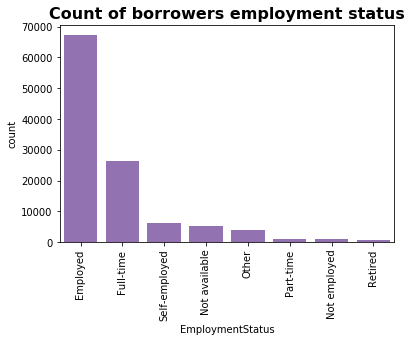

```python
#As I'll be using bar charts for many categorical features in the dataset I'll create a function to avoid repetion
def chart_cat(col,x):
    """ Takes a df column and create a decending ordered bar chart of the unique values of the column with seaborn countplot """
    freq = loans[col].value_counts();
    gen_order = freq.index
    base_color = sb.color_palette()[4]

    sb.countplot(data=loans, x=col, color=base_color, order=gen_order);
    plt.title(x,fontsize=16, fontweight='bold')

    plt.xticks(rotation=90);
    plt.figure(figsize=[8, 5]);
    return plt.show();

chart_cat('EmploymentStatus','Count of borrowers employment status')
```

##### Observation 2:

> Most of the borrowers are employed and full-timers , interestingly the number of self-employed borrowers is greater than that of part-timers. It's obvious that being employed is a main requirment and factor for the borrower to get a loan.

##### Q3: How many loans are completed , charged off and defaulted?

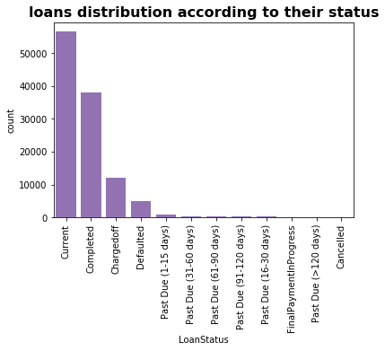

```python
chart_cat('LoanStatus', 'loans distribution according to their status')
```

##### Observation 3:

> Looking at the loan status we can say that most of the loans are in their current state which represent more than 50k of the loans , however a non small number of the loans is in the charged off state which is more than 10K , we need to have a closer look with percentages.

```python
#separating the major 4 row values and neglect others and get them ready to be in a pie chart
l = loans.loc[(loans['LoanStatus'] == 'Current')]
m = loans.loc[(loans['LoanStatus'] == 'Completed')]
n = loans.loc[(loans['LoanStatus'] == 'Chargedoff')]
o = loans.loc[(loans['LoanStatus'] == 'Defaulted')]
```

```python
print(len(l),len(m),len(n),len(o))
```

```
56576 38074 11992 5018
```

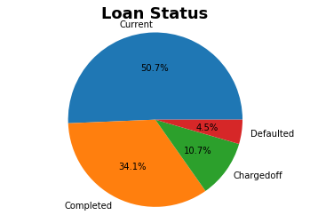

```python
my_data = [56576,38074,11992,5018]
my_labels = 'Current','Completed','Chargedoff','Defaulted'
plt.pie(my_data,labels=my_labels,autopct='%1.1f%%')
plt.title('Loan Status',fontsize=18, fontweight='bold')
plt.axis('equal')
plt.show()
```

##### Observation 3 - cont:

> A 10.7% which represent more than 11K loans in the chargedoff state is a big number that indicate losses and bad impacts for the lender side

##### Q4: What are the common income ranges between the borrowers?

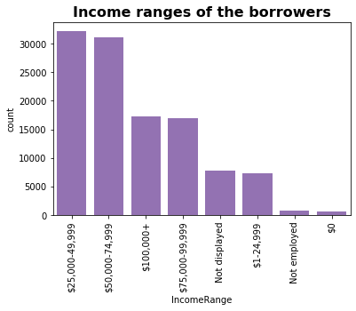

```python
chart_cat('IncomeRange','Income ranges of the borrowers')
```

##### Observation 4:

> 2 income ranges dominate on this dataset which represent the average incomes which are

1- 25k to 50k dollar

2- 50k to 75k dollar

##### Q5: What's the distribution of the lender yield?

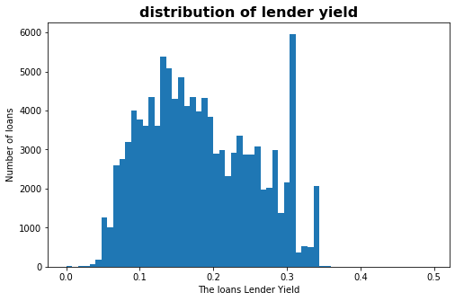

```python
# start with a standard-scaled plot
binsize = 0.008
bins = np.arange(0, loans['LenderYield'].max()+binsize, binsize)

plt.figure(figsize=[8, 5])
plt.hist(data = loans, x = 'LenderYield', bins = bins)
plt.xlabel('The loans Lender Yield')
plt.title('distribution of lender yield',fontsize=16, fontweight='bold')
plt.ylabel('Number of loans')
plt.show()
```

##### Observation 5:

> Closer look at the histograms of the lender yield on the loan shows concentration in the middle and the distribution looks roughly bimodal, with one peak between 10% and 20%, and a second peak a little above 30% .

##### Q6: What's the distribution of the borrower annual percentage rate?

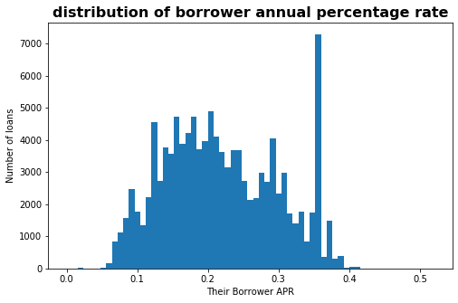

```python
# start with a standard-scaled plot
binsize = 0.008
bins = np.arange(0, loans['BorrowerAPR'].max()+binsize, binsize)

plt.figure(figsize=[8, 5])
plt.hist(data = loans, x = 'BorrowerAPR', bins = bins)
plt.title('distribution of borrower annual percentage rate',fontsize=16, fontweight='bold')
plt.xlabel('Their Borrower APR')
plt.ylabel('Number of loans')
plt.show()
```

##### Observation 6:

> Closer look at the histograms of the Borrower's Annual Percentage Rate (APR) for the loan shows concentration in the middle and shows a strong peak between 30% and 40%

##### Q7: What are the common loan amounts requested by the borrowers , What's the ditribution of loan original amounts?

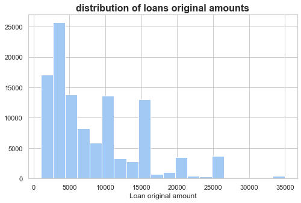

```python
#seeing the loans original amounts distribution
plt.figure(figsize=[8, 5])
plt.hist(data = loans, x = 'LoanOriginalAmount', bins = 20)
plt.title('distribution of loans original amounts',fontsize=16, fontweight='bold')
plt.xlabel('Loan original amount')
plt.show();
```

##### Observation 7:

> We can say easily from the histogram that numbers of low amount loans is bigger than the number of high amounts loans , which means that the small size loans are more likely to be accepted.

> Finally I was really interested to know what are the top professions of the borrowers who apply on loans and the least jobs too.

##### Q8: What are the most common occupations of the borrowers?

```python
loans['Occupation'].value_counts()
```

```
Other                          28617
Professional                   13628
Computer Programmer             4478
Executive                       4311
Teacher                         3759
                               ...
Dentist                           68
Student - College Freshman        41
Student - Community College       28
Judge                             22
Student - Technical School        16
Name: Occupation, Length: 67, dtype: int64
```

### Discussing the distributions of my variables of interest. Were there any unusual points? Did we need to perform any transformations?

> There're not points that are very unusual, What may be considered a transformation when I did subset the 4 main values in the loan status to be able to see their actual percentages that was tricking in the bar chart however after excluding them to a pie chart we could see big percentage of charged off loans.

### Of the features you investigated, were there any unusual distributions? Did you perform any operations on the data to tidy, adjust, or change the form of the data? If so, why did you do this?

> Some columns their nulls represented values like the total prosper loans , null means that they didn't take a loan before so I replaced TotalProsperLoans---to--- ScorexChangeAtTimeOfListing columns nulls with zeros so when analysis they can get into count and visualization easily.

## Bivariate Exploration

> In this section, we are going to investigate relationships between pairs of variables in your data.

##### Q1: How strong is the relationship between borrower annual rate and the lender yield, How does it look like?

[output not shown]

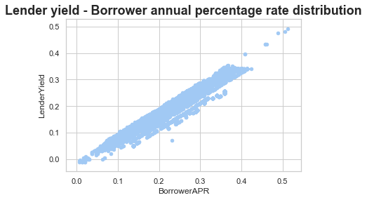

```python
loans.plot.scatter(x='BorrowerAPR', y='LenderYield');
plt.title('Lender yield - Borrower annual percentage rate distribution',fontsize=18, fontweight='bold');
```

##### Observation 1:

A strong linear relationship between the borrower annual rate and the lender yield , the lender yield increase when the borrower annual rate percentage increase.

We also notice a concentration and steady distribution of points along borrower annual percentage of values 0.1 "10%" to 0.4 "40%" and few outliers below the linear line in addition of much less distribution and concentration when the borrower annual rate percentage goes above 40%.

##### Q2: Is there a relationship between the estimated effective yield and the borrower rate ?

[output not shown]

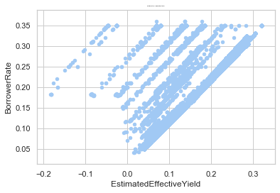

```python
loans.plot.scatter(x='EstimatedEffectiveYield', y='BorrowerRate');
plt.title('Estimated effective yield - Borrower rate distribution',fontsize=1, fontweight='bold');
```

##### Observation 2:

> A good linear correlation shown between the borrower rates and the estimated effective yield which is cutted to many linear lines that represents ranges and categories.

##### Q3: What's the dirtibution of each employment status according to the lender yield?

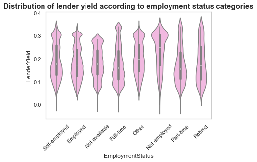

```python
base_color = sb.color_palette()[6]
sb.violinplot(data=loans, x='EmploymentStatus', y='LenderYield', color=base_color, innner=None);
plt.title('Distribution of lender yield according to employment status categories',fontsize=15, fontweight='bold');
plt.xticks(rotation=45);
```

#### Observation 3:

###### Not employed

The first thing we will notice here comes to the not employed category where you will be able to see that it has much higher mean in comparison to the other categories.

You will notice that lenders can make more profit rates "yield" from the not employed category as definitely they apply higher borrower rates.

###### Part-timers and retired

Vise versa of the previous can be seen on part-timers and retired categories , most of them the lender get less yield on their loans.

We can add to the part-timers team the full-timers category however a small note has to be added there's some concentration at the maximum , that means that a non-small number of the full-timers fall for higher borrower annual rates and so a higher lender yield.

##### Q4: For the charged off, current and completed loans , how many of these loan borrowers are home owners?

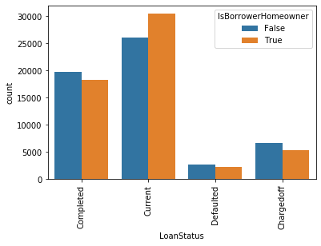

```python
loans1 =loans.loc[(loans['LoanStatus'] == 'Completed') | (loans['LoanStatus'] == 'Current') | (loans['LoanStatus'] == 'Chargedoff') | (loans['LoanStatus'] == 'Defaulted')]
sb.countplot(data = loans1, x = 'LoanStatus', hue = 'IsBorrowerHomeowner')
plt.xticks(rotation=90);
```

##### Observation 4:

> I can see that the lender is focusing on borrowers who have homes more as most of the charged off and defaulted loans made by borrowers who don't own a home.

##### Q5: Do the borrowers with previous prosper loans get less numbers of investors in their loans?

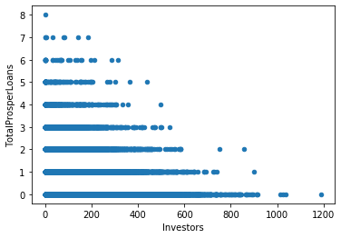

```python
loans.plot.scatter(x='Investors', y='TotalProsperLoans');
```

##### Observation 5:

> This correlation shows that people who has loans before are less likely to have investors in their current loans

##### Q6: What are the income ranges that get higher borrowers rates ?

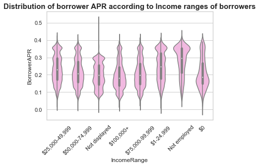

```python
sb.violinplot(data=loans, x='IncomeRange', y='BorrowerAPR', color=base_color, innner=None);
plt.title('Distribution of borrower APR according to Income ranges of borrowers',fontsize=15, fontweight='bold');
plt.xticks(rotation=45);
```

##### Observation6:

> The not employed borrowers get higher borrower rates and that's make it weird seeing that those with 0 dollars income get lower borrower rates.

##### Q7: What are the relationships of loan status and Income ranges with features like lender yield and prosper score ?

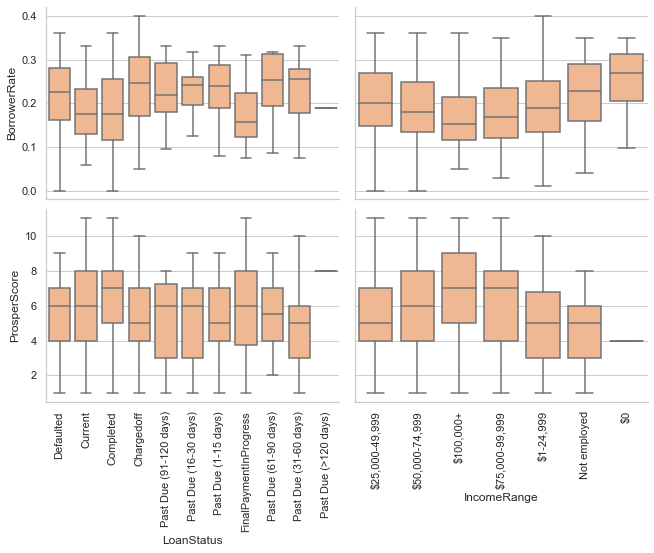

```python
samples = np.random.choice(loans.shape[0], 10000, replace = False)
loans_samp = loans.loc[samples,:]

def boxgrid(x, y, **kwargs):
    """ Quick function for creating box plots with seaborn's PairGrid with labels rotated """
    def_color = sb.color_palette()[1]
    sb.boxplot(x, y, color = def_color);
    plt.xticks(rotation=90);

plt.figure(figsize = [10, 10])
f = sb.PairGrid(data = loans_samp, y_vars = ['BorrowerRate','ProsperScore'], x_vars = ['LoanStatus','IncomeRange'],
                size = 3, aspect = 1.5);

f.map(boxgrid)
plt.show();
```

#### Observation 7:

##### Looking at the graph of prosper score and the loan status

Looking at the completed and the charged off categories , Most of the charged off loans was for those with lower prosper score and we can see that people with higher prosper scores were able to complete their loans payments. This is also noticable in the mean difference between both categories.

##### Looking at the graph of Borrower rate and the loan status

We can see that the higher the borrower rates the more likely the borrower not be able to pay off and the loan be charged off. As we can see in a comparison between completed and charged off. The borrower rates are less in the completed and higher in the charged off.

### Talk about some of the relationships you observed in this part of the investigation. How did the features of interest vary with other features in the dataset?

> A strong linear relationship between the borrower annual rate and the lender yield , the lender yield increase when the borrower annual rate percentage increase.

> Most of the charged off loans was for those with lower prosper score.People with higher prosper scores were able to complete their loans payments.

> Most of the charged off loans are for borrowers who don't own a home.

> People who has prosper loans are less likely to have investors in their current loans.

### Did you observe any interesting relationships between the other features (not the main feature(s) of interest)?

> The distribution of the relationship between Borrower rates and income range. The not employed borrowers get higher borrower rates and that's make it weird seeing that those with 0 dollars income get lower borrower rates.

## Multivariate Exploration

> Create plots of three or more variables to investigate your data even further. Make sure that your investigations are justified. Nfsy ab2a btatsaya wallahy.

##### Q1: Is "the borrower being in a group when listing" related to the lender yield and employment status , does it explain the distribution in observation 3 in the previous part ?

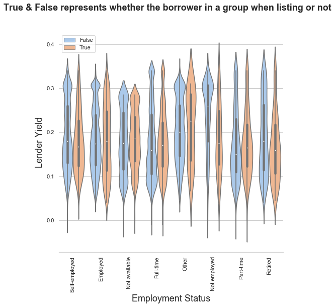

```python
sb.set(style="whitegrid", palette="pastel", color_codes=True)

f, ax = plt.subplots(figsize=(8, 8))

sb.violinplot(x='EmploymentStatus', y='LenderYield', hue="CurrentlyInGroup", data=loans)
sb.despine(left=True)
plt.xticks(rotation = 90)

f.suptitle('True & False represents whether the borrower in a group when listing or not', fontsize=18, fontweight='bold')
ax.set_xlabel("Employment Status",size = 18)
ax.set_ylabel("Lender Yield",size = 18)
plt.legend(loc='upper left')
```

##### Observation 1:

We noticed before the not employed large distribution with high lender yield but we can defintely notice now that most of these distribution are for those who weren't in a group when listing loans.

##### Q2: How the loans are distributed according to their status inside the relationship between the borrower rates and the estimated effective yield?

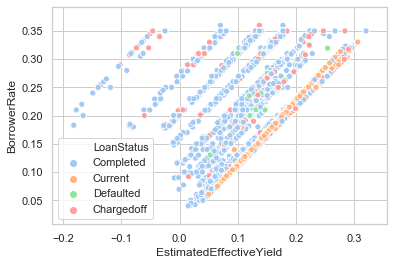

```python
sb.scatterplot(data = loans1, x='EstimatedEffectiveYield', y='BorrowerRate', hue='LoanStatus')
```

##### Observation 2:

> We can see that the current loans are more steady and concentrated when the estimated effective yield is bigger than 0. Also we can see the rest of the loan status are equally distrbuted on the linear ranges.

##### Q3: How the borrowers are distributed according to their status as home owners inside the relationship between the borrower rates and the estimated effective yield?

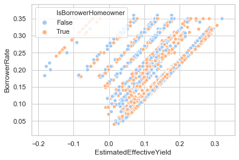

```python
sb.scatterplot(data=loans ,x='EstimatedEffectiveYield', y='BorrowerRate',hue="IsBorrowerHomeowner");
```

##### Observation 3:

> Being a home owner doesn't make a real difference for borrower rates and estimated effective yield. All are distributed equally.

##### Q4: Does it make it a difference in the lender yield wether the borrower own a home or not as long as he has the same income range?

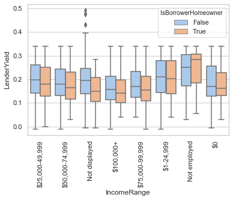

```python
sb.boxplot(data=loans,x='IncomeRange',y='LenderYield',hue="IsBorrowerHomeowner");
plt.figsize=(8, 8)
plt.xticks(rotation=90);
```

##### Observation 4:

> We can see borrowers owning home have lower averages of lender yield even though they have the same income range. However the differences between the 2 groups averages are not much.

> Except in the not empolyed category, interestingly the home owners have the highest rates of lender yield and they're highher than those who don't own a home in the same category

```python
#!jupyter nbconvert project3submit.ipynb --to slides --TemplateExporter.exclude_input=True --ServePostProcessor.port=8930 --post serve
```